# Unsupervised Learning

## Principal Component Analysis (PCA)

For our unsupervised learning model, we decided to work on PCA in order to see the clusters formed and study the important components of each of the Home and Away teams.

*Graphing of Variables*

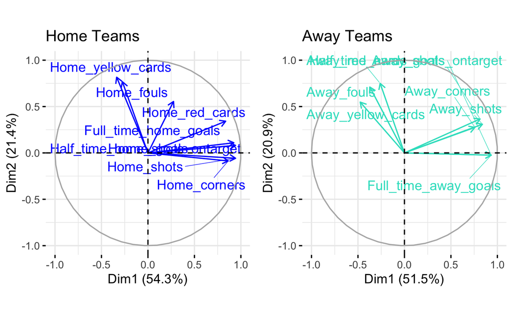

*Contribution of Variables*

To better interpret these dimensions, we can extract the contributions of each features in the dimension. Below, for Dimension1. We can see below the graphs showing contributions of each variable in both Home and Away states. We can conclude that whether the teams are playing Home or Away, there isn’t a huge change in the contribution of the variables.

Further, as shown in the variable graphs, the variables *yellow cards*, *red cards*, and *fouls* are correlated with Dimension 2.

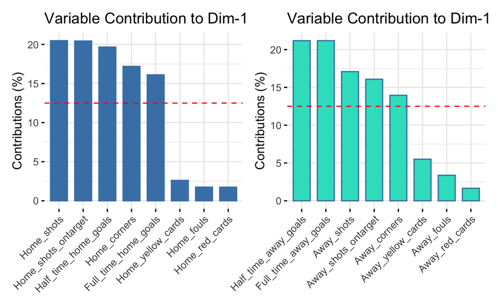

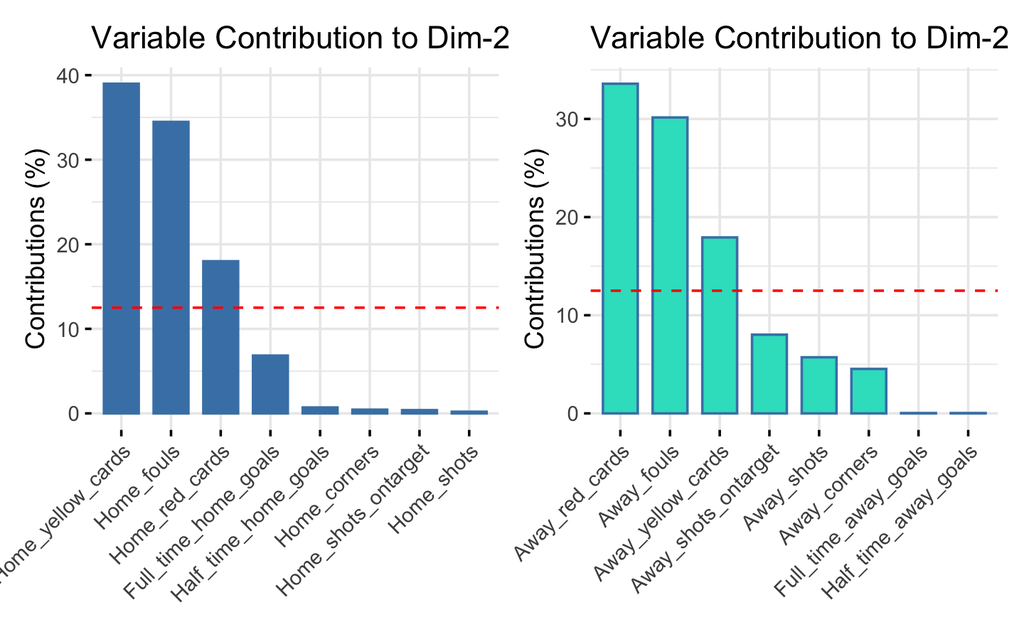

*Dimension Analysis*